# Project 1 - Part 1: Overflowing the Stack

## I. Understanding Foundational Concepts - (10 points)

1. **What is a pointer?**
   - A pointer is variable which stores the address of another varible
1. **How i_s memory managed differently between say “C” and “Java”?**
   - In "C", programmers needs to manage memory themselves, while in "Java", which is more high-level, the Java compiler will manage memory.
1. **When is memory allocated and deallocated in “C”? Answer both static and dynamic memory.**
   - Dynamic
     - Stack: allocated when a function is called, deallocated when the funciton is returned
     - Heap: allocated when `malloc()` is called, deallocated when `free()` is called
   - Static
     - allocated using `static` key word, deallocated when the whole program ends
1. **Would it be smart to use fixed-width integer types? Explain.**
   - No, because different C compliers in different systems will be different, and some system doesn't support some fixed-width integer
1. **What is the difference between “compile time” and “run time”?**
   - "Complie time" means the source code is being complied into machine code by a complier, "run time" means the complied machine code is being execute.
1. **Give an example of a variable declaration and definition at compile time. Then give an example of this variable being redefined during run time. Finally, show an allocation of memory during runtime. Provide code examples in “C”.**
   1. declare and define a:

      ```
      #include <stdio.h>
      #include <string.h>

      int main (int argc, char *argv [])
      {
       int a = 0;
       a = 1;
      }
      ```

   2. allocation during runtime:

      ```
      #include <stdio.h>
      #include <string.h>

      int main (int argc, char *argv [])
      {
       int* a = malloc(sizeof(64));
      }
      ```

1. **What is the difference between an assembler, compiler, and an interpreter?**
   - assembler: transform assembly code to machine code
   - compiler: transform source code to machine code or assembly code
   - interpreter: transform source code to machine code at run time
1. **Is C a compiled language? Is Python? If either answer is no, how is the language processed so code can be run?**
   - C is, but Python is not. C needs to be complied to machine code to run, while Python needs interpreter to transform source code to machine code at run time.
1. **What is the GNU compiler? How do you invoke the GNU Compiler?**
   - GNU compiler is developed for GNU project and support many languages, includes C
   - invoke using `gcc -[parameters]`
1. **What is GDB? In GDB, how would you:**
   - **View the processor registers**
     - `info registers`
   - **Set a breakpoint in code**
     - `break *(address)
   - **Find the address of an OS Function**
     - example: for system() `p system`
   - **Inspect a memory location**
     - `x *(location)`

## III. Compiler Flag Options - (12 points)

1. `-O0`
   - Reduce compilation time and make debugging produce the expected levels.
1. `-g`
   - Generate debugging information
1. `-fno-stack-protector`
   - Turn of stack protection such as stack canary
1. `-z execstack`
   - Mark the stack as executable stack

## IV. Buffer and Heap Understanding - (12 points)

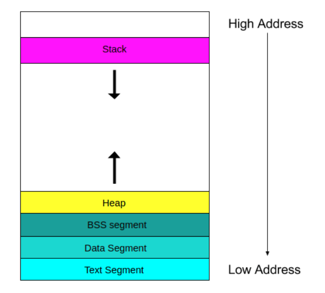

source: https://medium.com/@SravanthiSinha/all-about-the-virtual-memory-1c8a3cf306b7

1. **Where in memory is the stack located and in which direction does it grow?**
   - Stack is used in VM to process functon calls. Stack’s locaton on VM are show above. VM locate Text/Data/BSS Segment frst at a lower address, while allocate stack at a higher address.
   - Stack grows from a high address to a low address
1. **How is data stored and organized on the stack?**
   - When a new stack frame is created, it first push the return address into the stack, and push the ebp pointer's value. Then the stack pointer create some offset to store local variables for the current function call.
1. **Explain how program control flow is implemented using the stack.**
   - When a functon is called, rellevant values are push to the stacks, such as parameters passed to the functon and the return address. Then a new stack frame is created to store local variables. When the called functon ends, stack pop the functon’s stack frame of the stack and return controll to the return address.
1. **Where in memory is the heap located and in which direction does it grow?**
   - Heap as showing above picture, is allocated after the data/text/oss segment
   - Heap grows from lower address to higher address
1. **How is data stored and organized on the heap?**
   - The data structure in heap is like a hash table, one pointer point to a certain memory locaton in heap. Heap is contiguous inside of a chunk, between chunks, it might not be contiguous.
1. **What kind of program data goes to the stack versus the heap? Where are global variables stored?**
   - Local varibles of a function go to the stack, while global variables created using `malloc` goes to the heap

## V. Stack Overflow - (29 points)

screenshot:

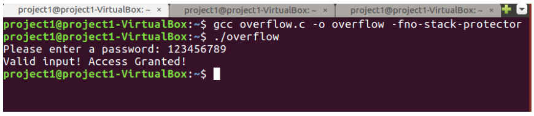

### Stack Overflow Diagram (18 points)

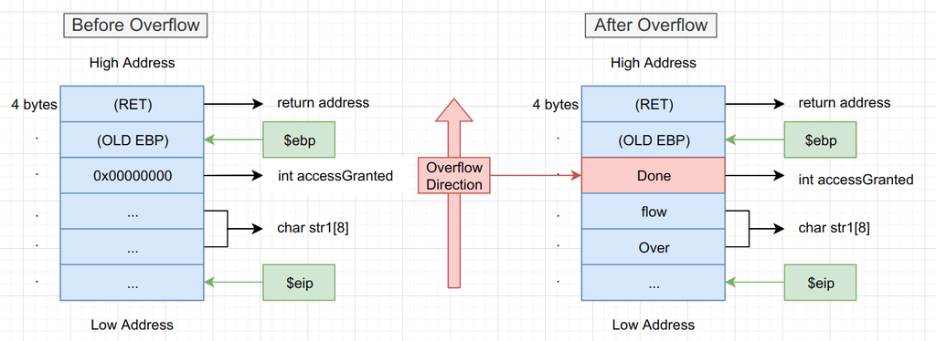